# Dice Probability

Anna Hasselwander

4/3/2018

# Dice Probability

We are interested in understanding the most likely outcome of rolling a pair of fair dice n times. This web page was built using a language called “R”, which is very useful for doing math and statistics. It was then “knit” into a webpage using an offshoot of this language called “RMardkown”.

## First we make two functions: One to simulate dice rolls, and another to plot them as a “histogram”. A histogram is a kind of plot that shows the number of observations in a number of bins. In this case, each “bin” is a possible outcome of the role of two fair dice.

```r
dice <- function(n = 50) {
  trials <- vector()
  for(i in 1:n) {
    a <- sample(1:6, 1)
    b <- sample(1:6, 1)
    c <- a+b
    trials <- c(trials, c)
  }
  trials <- data.frame(trials)
  return(trials)
}

trial_50 <- dice(50)

makeDicePlot <- function(data) {
ggplot(data, aes(x = trials)) +
        geom_bar(aes(y = (..count..)/sum(..count..), color = trials)) +
        scale_y_continuous(labels=percent) +
        scale_x_continuous(breaks = c(1:12)) +
        geom_text(aes( label = scales::percent(..prop..),
                   y= ..prop.. ), stat= "count", vjust = -.5) +
        labs(y = "Percent", x = "Sum of Dice")
}
```

## N = 50

For a relatively small number of rolls, the distribution of probabilities is less precise than the “population” distribution.

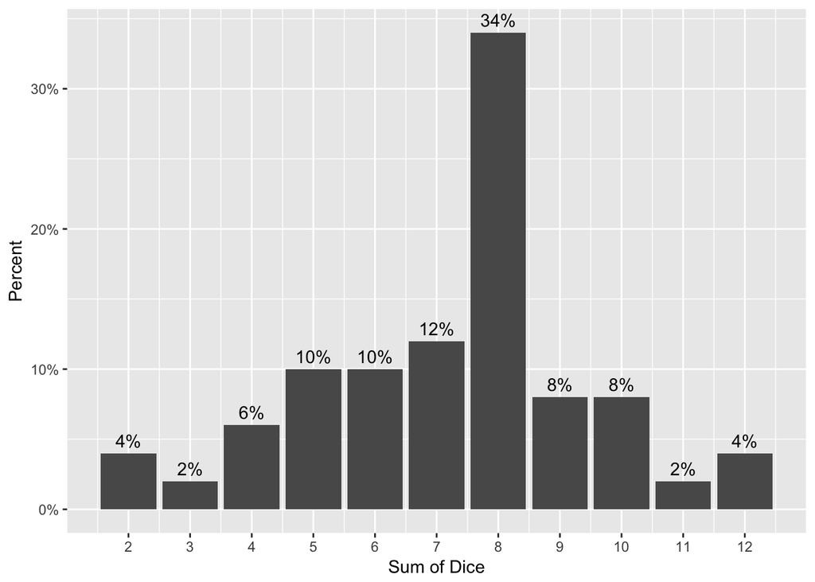

```r
makeDicePlot(trial_50)
```

## N = 250

For a medium-sized number of rolls, the distribution of rolls approximates the “population” distribution.

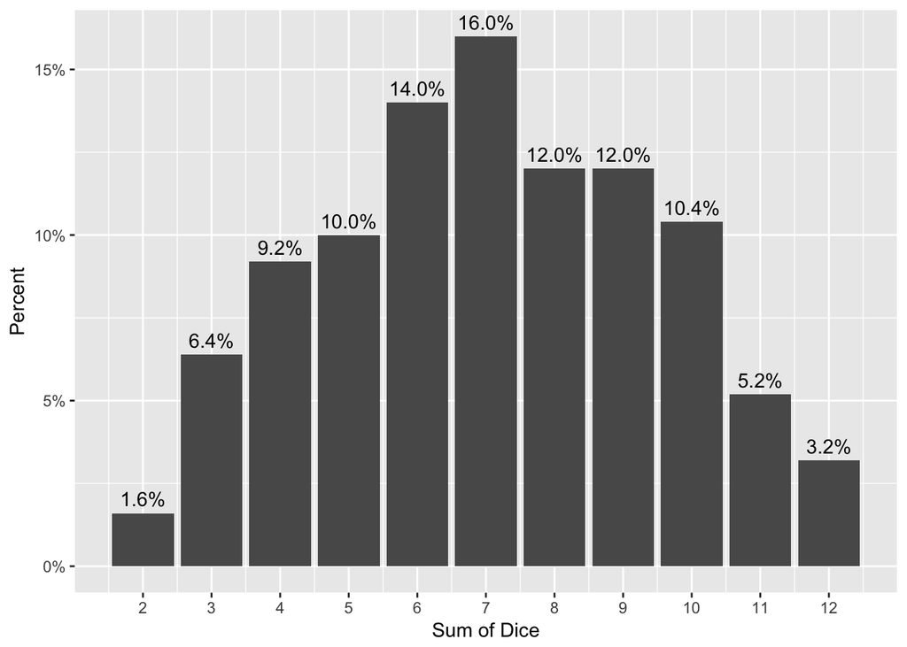

```r
trial_250 <- dice(250)
makeDicePlot(trial_250)
```

## N = 50,000

For a more “true” simulation, approaching the population distribution, we can see the percentage of rolls in each bin. It won’t vary much after this!

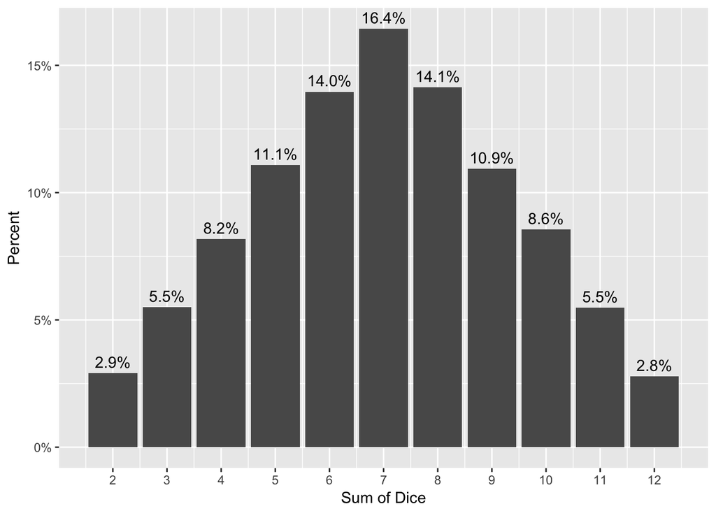

```r
trial_50K <- dice(50000)
makeDicePlot(trial_50K)
```

## N = 1,000,000

Now this takes a long time to simulate. How about ONE MILLION rolls???

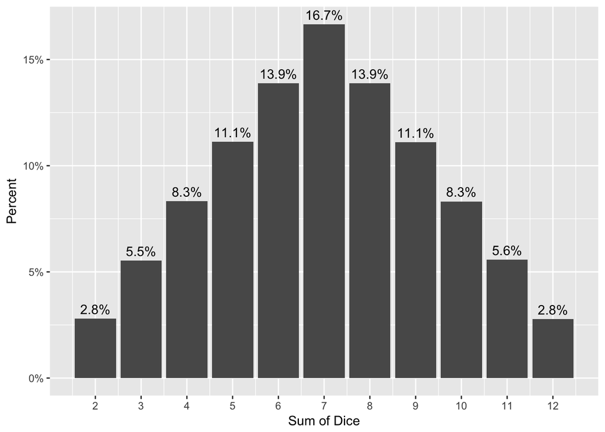

```r
trial_1M <- dice(1000000)
makeDicePlot(trial_1M)
```